# Midterm Project: Hedonic Home Price Prediction

Nikhil Tangirala, Jonathan Yuan

November 11, 2018

# Introduction

This analysis seeks to create a model that predicts home sale prices in Nashville, based on existing sales data obtained from Zillow. This model uses existing data on the locations of public amenities, geographic features, and demographic makeup with regards to previous home sales, in order to predict future sales. Developing a robust model will help Zillow more accurately predict home prices, which will lead to an overall greater access to information for both homebuyers and sellers.

Although Zillow's predictions are not official appraisals, buyers and sellers often use Zillow's price predictions to gain an idea of the expected price of a property. Improving the methodology used to obtain these predictions will help ensure that people are not misinformed when buying or selling a home. This task is difficult due to the numerous factors that are implicated in home prices, many of which may be difficult to obtain data for. This model is thus limited in that it relies on openly available data on a limited set of amenities and public facilities. There are likely many other variables that were not included in the model that would have a significant effect on home prices. Nevertheless, this analysis aims to create the most robust model possible with the data available.

Ultimately, our model was able to predict housing sale prices with 67% accuracy and a remarkably high average error of about $90,000. The strategy used to develop this model includes first removing 649 (of 10,000) mostly vacant properties, which lack a substantial amount of data. We then develop a multiple regression model and use 100-fold cross-validation to test the generalizability of the model on 100 randomly selected samples.

# Data

Data was collected from various sources to make up the explanatory variables for the model. Various datasets on public amenities and facilities were obtained from the City of Nashville, including locations of public art and parks. Other geographic feature datasets were obtained from OpenStreetMap, including railways, roads, and water bodies. Demographic data was obtained at the census tract level from the 2016 American Community Survey. Zillow's home sales data also contained individual property characteristics, such as square footage and physical depreciation. Data was chosen based on availability and on hypotheses regarding which variables might be implicated in determining home prices.

## Dependent Variable: Sale Price

Our model uses the log-transformed sale price as the dependent variable. The distribution of prices is significantly right-skewed, with a median of just $232,000 compared to a mean of $322,473. Furthermore, we anticipated that the relationship between Sale Price and other variables is non-linear, so a logarithmic transformation was applied, as is typical for relationships based on percent change rather than unit ($) change.

Note: there are 999 missing values because these are the properties for which a price needs to be predicted.

| Stats | SalePrice |
| --- | --- |
| **Description** | Observed sale price |
| **Transformation** | log(SalePrice) |
| **Missing values** | 999 |
| **0 pct (min)** | 1562 |
| **25 pct (1st)** | 148400 |
| **50 pct (med)** | 232000 |
| **75 pct (3rd)** | 389000 |
| **100 pct (max)** | 6894305 |
| **Mean** | 322473 |

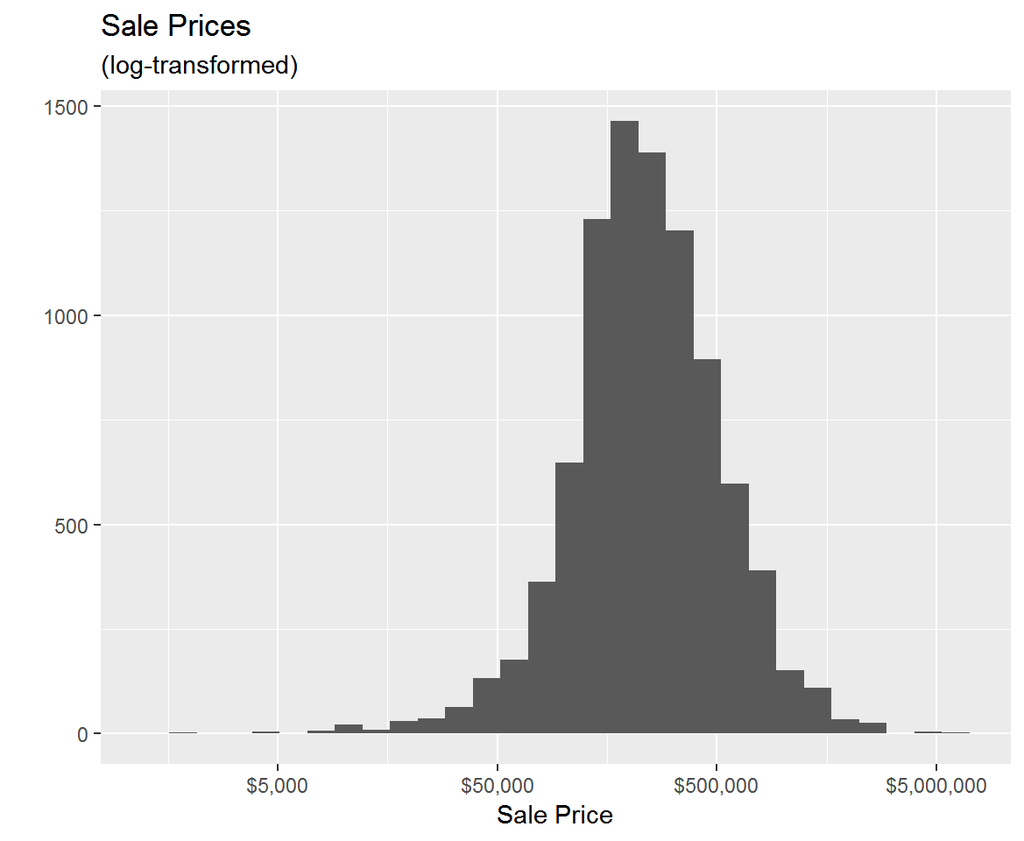

A map of sale prices is below. Sales prices exhibit significant clustering, with the most expensive homes largely clustered in the southwestern portion of the city, while the least expensive properties are primarily found to the north and southeast. The downtown area has a range of moderately-priced homes in yellow.

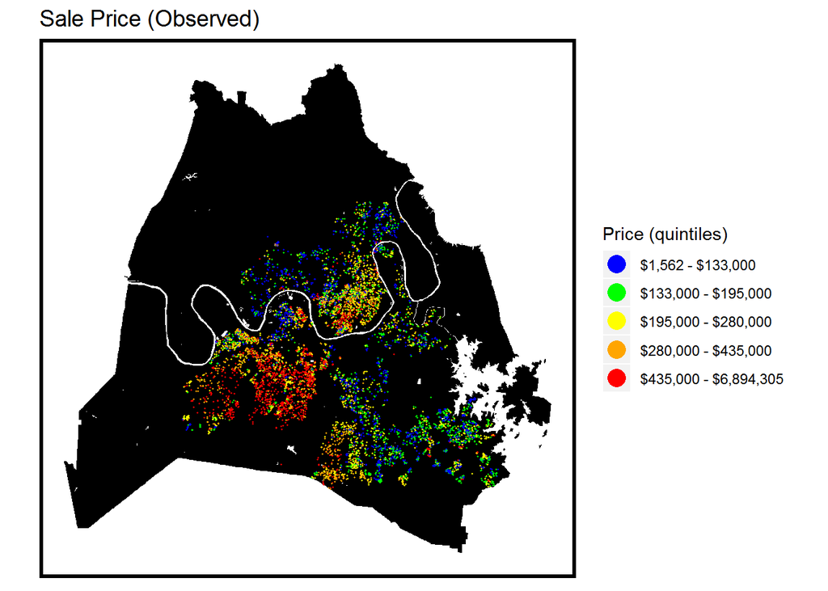

## Independent Variables

Over 100 variables and transformations were created (a process called feature engineering) to build an effective model. Eighty-one original variables are listed here, and selected descriptions and summary statistics are provided further below.

| Independent Variables |  |  |  |  |  |  |
| --- | --- | --- | --- | --- | --- | --- |
| X1mi_BLDGS | LocationZip | LandUseFull | sf_finished | d3PubArt | PCT_MGMT | PCT_ASIAN |
| DIST2 | LocationCity | yearbuilt | sffin_less_bfin | dBID | P_NATRES | HAS_PACIF |
| DIST5 | CouncilDistrict | effyearbuilt | sf_bsmt | dWATER | PCT_SERVIC | PCT_PACIF |
| DIST10 | TaxDistrict | HeatingType | sf_bsmt_fin | PCT_NONFAM | P_SALESOFF | HAS_NATAM |
| PRICE2 | SCH_DISTRI | centralair | rooms | AVG_HHSIZE | P_PRODTRAN | PCT_NATAM |
| PRICE5 | Building_Type | Fixtures | bedrooms | OWNER_OCC | BACH_DEG | PCT_OTHRAC |
| PRICE10 | Exterior_Wall | Story_Height | baths | RENT_OCC | HS_DEG | fclass |
| OwnerOnsite | Frame | Story_Num | halfbaths | DENSsqmi | MEDHHINC | dROADS |
| OwnerInZIP | Foundation | Story_Floor | units | OCCPOPDENS | POV_PERC | oneway |
| OwnerInTown | AvgHtfl_com | Story_Ceil | dHWY | LABORPARTI | PCT_WHITE |  |
| OwnerInState | Phys_Depreciation | Story_Split | dRAIL | UNEMP | PCT_BLK |  |
| GEOID | Phys_Dep_num | sf_gross | dPARK | MGMT_DENS | HAS_ASIAN |  |

### Property characteristics

Property characteristics, including square footage, frame materials, and physical condition, were considered for this model. As mentioned in the introduction, 649 properties were missing significant portions of data, including square footage, units, effective year built, and physical depreciation.

| Stats | sf_gross | sf_finished | sffin_less_bfin | units | effyearbuilt |
| --- | --- | --- | --- | --- | --- |
| **Description** | Gross square footage | Total finished square footage | Total finished square footage not including basement | Number of dwelling units | Effective year built (adjusted for significant renovations or neglect) |
| **Transformation** | log(sf_gross) | log(sf_finished) | sqrt(sffin_less_bfin) | No transformation | No transformation |
| **Missing values** | 641 | 649 | 649 | 649 | 649 |
| **0 pct (min)** | 440 | 348 | 348 | 0 | 1832 |
| **25 pct (1st)** | 1537 | 1237 | 1213 | 1 | 1977 |
| **50 pct (med)** | 2267 | 1669 | 1596 | 1 | 1997 |
| **75 pct (3rd)** | 3073 | 2206 | 2147 | 1 | 2015 |
| **100 pct (max)** | 16671 | 10608 | 10608 | 4 | 2018 |
| **Mean** | 2493 | 1844 | 1785 | 1 | 1992 |

| Stats | Frame | Phys_Depreciation |
| --- | --- | --- |
| **Description** | Building frame type | Assessed building condition |
| **Transformation** | None (categorical variable) | None (categorical variable) |
| **Missing values** | NA: 0 | NA: 648 |
| **Values** | BLANK: 2692 | Dilapidated: 5 |
|  | RESD FRAME: 3876 | Very Poor: 11 |
|  | TYPICAL: 3432 | Poor: 32 |
|  |  | Fair: 138 |
|  |  | Average: 9106 |
|  |  | Good: 52 |
|  |  | Very Good: 6 |
|  |  | Excellent: 2 |

#### Selected Variable: Effective Year Built

Effective year built is the year of construction of the property, adjusted to take into account renovations and reinvestment that may make the property’s effective year built more recent than its actual year built. Properties with older effective ages tend to be located in the outskirts of the city to the north and west. Properties with newer effective ages appear to be more prevalent closer to the CBD. These trends shift to the southeast, however, where newer properties generally appear to locate farther from the CBD.

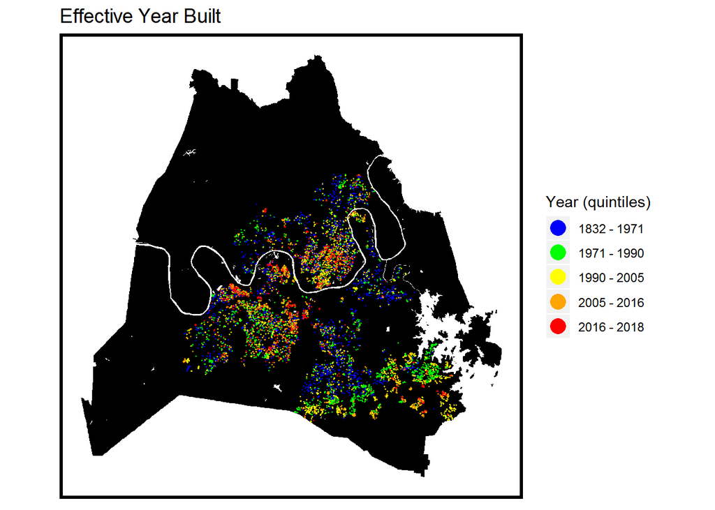

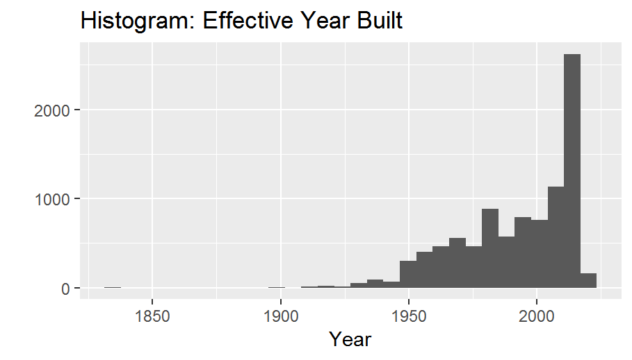

### Owner characteristics

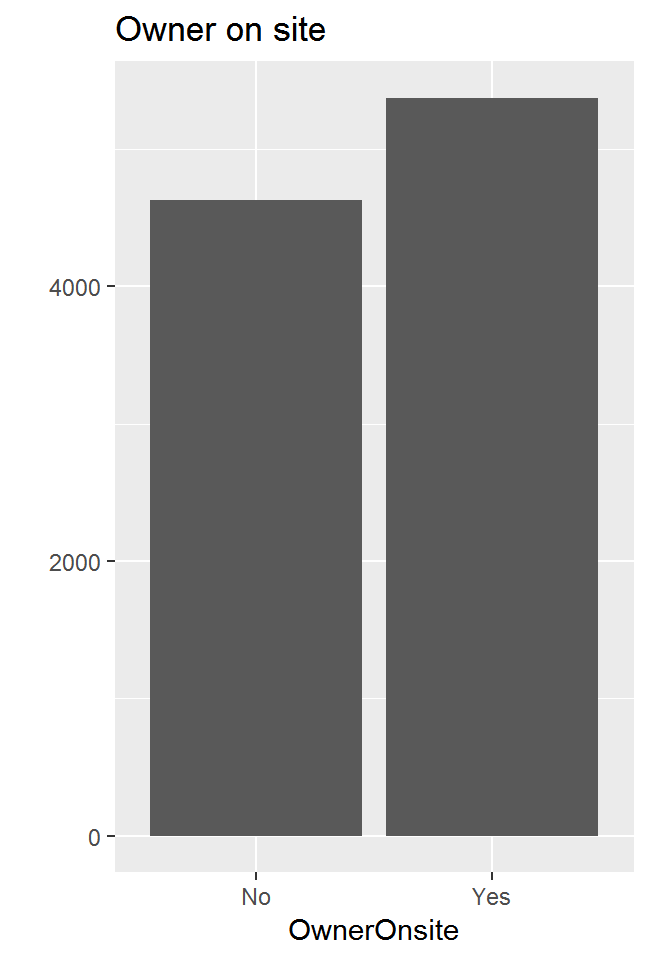

These owner characteristics were generated by comparing the seller's location with the property's location itself. It might be expected that owners that live off-site or out-of-state may be developers or real estate holders with more resources to sell the property at a higher price.

| Stats | OwnerOnsite | OwnerInZIP | OwnerInTown | OwnerInState |
| --- | --- | --- | --- | --- |
| **Description** | Owner lives at property (Yes/No) | Owner lives in property ZIP (Yes/No) | Owner lives in property city (Yes/No) | Owner lives in Tennessee (Yes/No) |
| **Transformation** | None (categorical variable) | None (categorical variable) | None (categorical variable) | None (categorical variable) |
| **Missing values** | NA: 0 | NA: 0 | NA: 0 | NA: 0 |
| **Values** | No: 4627 | No: 3410 | No: 1588 | No: 629 |
|  | Yes: 5373 | Yes: 6590 | Yes: 8412 | Yes: 9371 |

### Spatial characteristics

Location attributes such as distance to Business Improvement Districts (BIDs) or parks were considered. Census tract fixed effects are used to account for spatial differences across this geography.

| Stats | dBID | dPARK | Stats | GEOID |
| --- | --- | --- | --- | --- |
| **Description** | Distance to nearest BID (Nashville Central or Gulch) | Distance to nearest park | **Description** | Census Tract ID |
| **Transformation** | sqrt(dBID) | dPARK^(1/3) | **Transformation** | None (categorical variable) |
| **Missing values** | 0 | 0 | **Missing values** | NA: 0 |
| **0 pct (min)** | 245 | 6 | **Values** | 47037010105: 41 |
| **25 pct (1st)** | 12351 | 1026 |  | 47037010106: 53 |
| **50 pct (med)** | 21384 | 1816 |  | 47037010401: 34 |
| **75 pct (3rd)** | 37587 | 3100 |  | 47037010402: 70 |
| **100 pct (max)** | 72954 | 13897 |  | 47037010602: 25 |
| **Mean** | 25335 | 2339 |  | 47037010… |

#### Selected Variable: Distance to Business Improvement Districts

The two BIDs in Nashville—the Central Business Improvement District and the Gulch Business Improvement District—are both located near the downtown area. This map illustrates distance from these BIDs. It's noticeable that homes built more recently (Effective Year Built, above) tend to be closer to this same area.

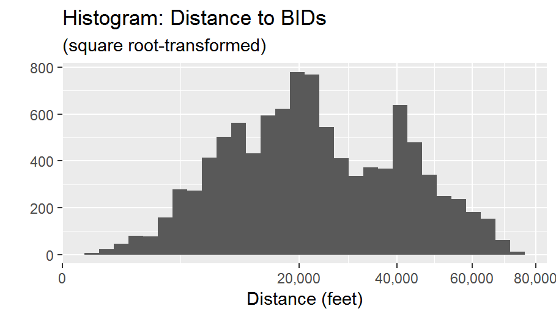

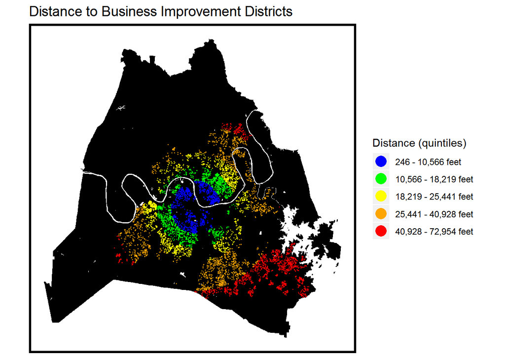

### Market Characteristics

Some pseudo-spatial characteristics proved to be highly effective in predicting sale price, especially the sale price of neighboring homes. (If a neighbor's home sold for $100,000, it's likely that your home would sell for a similar price.)

Our model found that the aggregated sale price of both 5 neighbors and 10 neighbors was significant, and also that distance to two nearest home sales was significant both as a cube root-transformed variable as well as an untransformed varable.

| Stats | PRICE5 | PRICE10 | DIST2 |
| --- | --- | --- | --- |
| **Description** | Mean sale price of 5 nearest properties | Mean sale price of 10 nearest properties | Mean distance to two nearest sales |
| **Transformation** | log(PRICE5) | log(PRICE10) | DIST2^(1/3); No transformation |
| **Missing values** | 0 | 0 | 0 |
| **0 pct (min)** | 18425 | 38357 | 1 |
| **25 pct (1st)** | 160426 | 163849 | 105 |
| **50 pct (med)** | 244580 | 251988 | 213 |
| **75 pct (3rd)** | 394303 | 403140 | 365 |
| **100 pct (max)** | 4927870 | 3659409 | 10832 |
| **Mean** | 322573 | 323910 | 271 |

#### Selected Variable: Mean Sale Price of 5 Nearest Properties

The map reveals a similar distribution of aggregated sale prices to individual sale prices, with more expensive homes clustered in the southwest, and less expensive homes clustered in the north and southeast of the city.

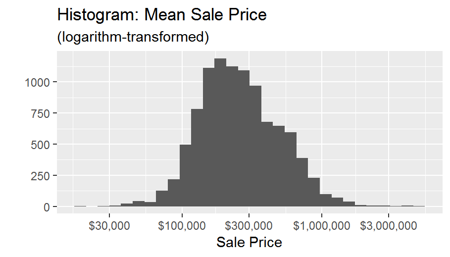

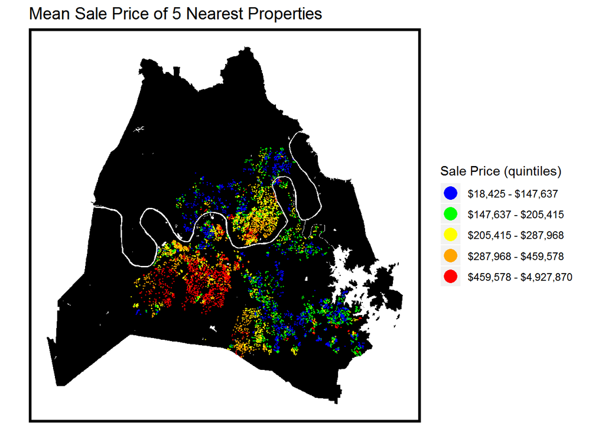

## Covariance

While building variables in preparation for a predictive model, we found that many variables were collinear, meaning that they increased or decreased at similar rates.

This matrix reveals this collinearity or covariance among property variables (gross square footage, finished square footage, and finished square footage excluding basement square footage), which is expected due to the fundamentally related nature of these variables. Additionally, there is significant covariance between the two market-price variables (average price of 5 nearest sales and average price of 10 nearest sales), which can be expected due to the nested nature of these variables.

Although these variables are significantly correlated, a predictive model adjusts for any redundancies while taking into account slight differences between similar variables.

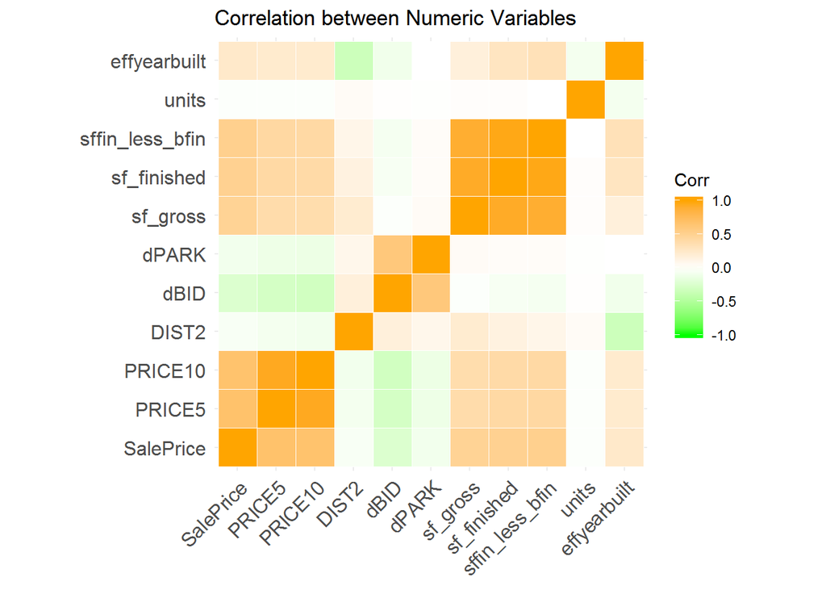

# Methodology

Once data was collected, it was matched to existing home sale data, which already carried property and owner characteristics. Certain spatial variables were incorporated by calculating the distance from each property to the nearest feature. For example, data on the location of parks was translated into a distance variable, where the distance from each property to the closest park was calculated. For zonal spatial variables, such as school district and census tract, each property was assigned the zone where it was located. Properties were also given census data that corresponded to the census tract each property was located in. This allowed us to examine the general demographic makeup of the surrounding area of each property. Finally, market characteristics were created that examined the distribution of sales, calculating the average distance to and average sale price of selected numbers of each property’s nearest sales.

Variables were then examined to get a sense of their distributions. Variables that were not linearly distributed were transformed, either through log-transformation, square-root transformation, or cube-root transformation, in order to yield more linear variables. Overall, including all transformed and untransformed variables, we were left with 100 independent variables.

As stated earlier, many of the individual property characteristics (like square footage and number of bedrooms) did not apply to vacant properties. As a result, these 649 vacant properties were removed from the analysis to maintain consistency.

In order to cross-validate the model, we used a 100-fold cross validation method, which randomly puts aside 1% of the data as a test set. It then predicts for this sample test set using the remaining 99% of the data as the training set. This process repeats 100 times until all of the data has been part of a test set in a single “fold” or iteration. The final output aggregates the model’s predictive characteristics across these 100 iterations, yielding average values for the R^2, adjusted R^2, mean absolute error, and mean absolute percent error values. This method helps to ensure the generalizability of the model.

# Results

## Final Model Output

Predicted sale price values are displayed below. As in the map of actual sale prices, higher prices are in the southwest, moderate prices near downtown, and lower prices elsewhere. We expected this to indicate that the model is fairly effective in its predictions. However, model results show that the error in predicted sale prices is fairly high.

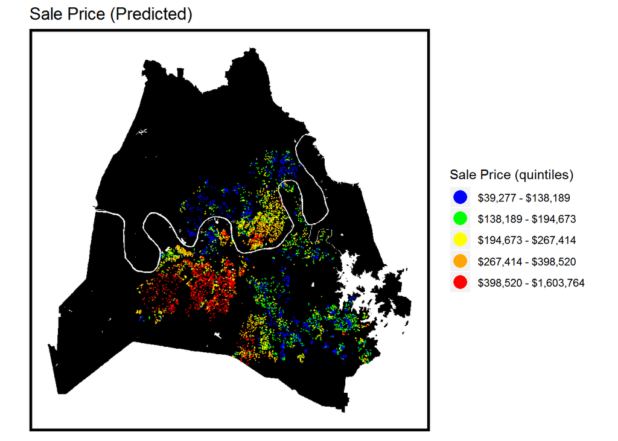

### Model Results

The model output is displayed below, along with the coefficients for each variable. The model has a fairly low R-squared of 0.666, accurately accounting for only 66.6% of variation in Sale Price. Additionally, the error of nearly $90,000 and over 35% is substantial.

The calculated coefficients for each variable is displayed on the right. For each unit change in the transformed dependent variable, there is a proportional change in the log-transformed sale price equivalent to the coefficient. For categorical variables, the proportion is 1.

| Model | Stats |
| --- | --- |
| Dependent Variable | SalePrice (log) |
| Independent Variables | PRICE5 (log) PRICE10 (log) DIST2 (curt) DIST2 dBID (sqrt) dPARK sf_gross (log) sf_fininished (log) sffin_less_bfin (sqrt) units effyearbuilt Frame Phys_Depreciation OwnerOnsite OwnerInZIP OwnerInTown … |
| R-squared | 0.666 |
| Mean Absolute Error | $88,187.53 |
| Mean Absolute Percent Error | 36.1% |

| Variables | Coefficients |
| --- | --- |
| (Intercept) | -0.4602213 |
| PRICE5_log | 0.2688582 |
| PRICE10_log | 0.1794086 |
| DIST2_curt | -0.0629189 |
| DIST2 | 0.0003899 |
| dBID_sqrt | -0.0015107 |
| dPARK | 0.0000120 |
| sf_gross_log | 0.2336783 |
| sf_fin_log | 0.1586955 |
| sffin_less_bfin_sqrt | 0.0056761 |
| units | -0.1391745 |
| effyearbuilt | 0.0020365 |
| FrameRESD FRAME | 0.0937134 |
| FrameTYPICAL | 0.1294433 |
| Phys_Dep_num | 0.0540398 |
| OwnerOnsite1 | 0.1751766 |
| OwnerInZIP1 | 0.1048212 |
| OwnerInTown1 | 0.0738504 |
| OwnerInState1 | -0.2493921 |
| GEOID47037010106 | -0.2446943 |
| GEOID47037010401 | 0.1743260 |
| GEOID47037010402 | 0.0774819 |
| GEOID47037010602 | -0.0002356 |
| GEOID47037010701 | 0.1280310 |
| GEOID47037010702 | 0.2685729 |
| GEOID47037010801 | 0.0606648 |
| GEOID47037010802 | 0.0823008 |
| GEOID47037010901 | 0.0569042 |
| GEOID47037010903 | 0.0879129 |
| GEOID47037010904 | -0.0763119 |

[output cut: 116 more lines]

## General Model Error

We examined errors and used *k*-fold cross-validation to assess the generalizability of the model. If accuracy of the model is unusually low for some portion of sale prices, then there is likely some variable that was not accounted for in the model.

### *k*-fold Cross Validation (*k* = 100)

In *k*-fold cross validation, 1% samples are randomly withheld from the model as a test set; the model trained on the remaining 99% is used to predict the test set. This is repeated for 100 "folds" to ensure that there is no systematically poor performance in predictions.

In the histogram on the right, a fairly normal distribution indicates that the model predicted test sets fairly consistently. Results from a sample fold (#80) are included below.

| Fold080 | Stats |
| --- | --- |
| R-squared | 0.597 |
| Mean Absolute Error | $89,680.51 |
| Mean Absolute Percent Error | 48.0% |

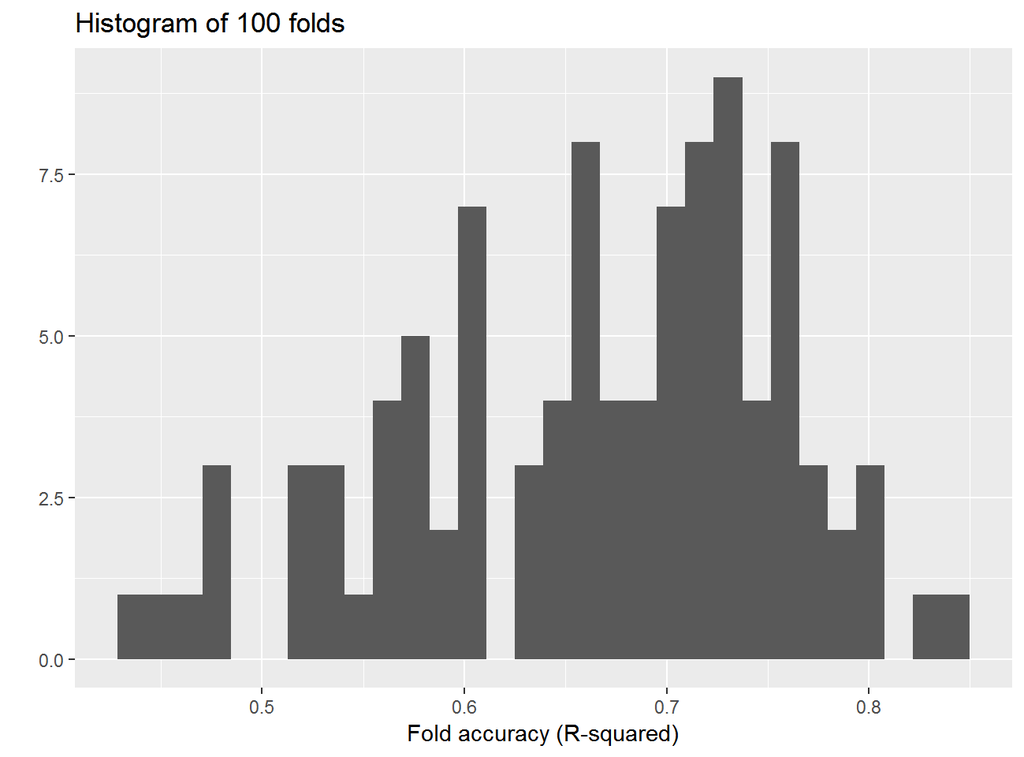

### Predicted vs. Actual Sale Price

Next, we examine model error in relation to sale price itself. In the graphs below, points above the red line mean that the actual sale price is higher than predicted sale price.

As you can see, some high-priced homes are under-predicted, including some homes that are nearly $7,000,000 that were predicted to be about $1,000,000. High-priced homes like this are typically outliers, however, and most error is relatively low and close to the red line.

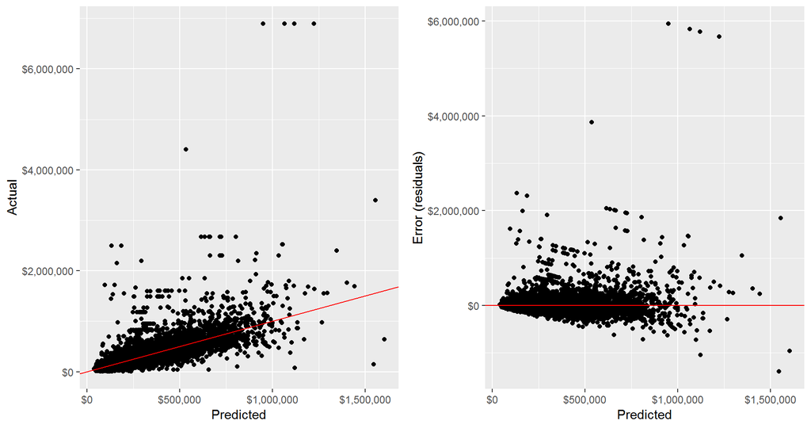

## Spatial Error

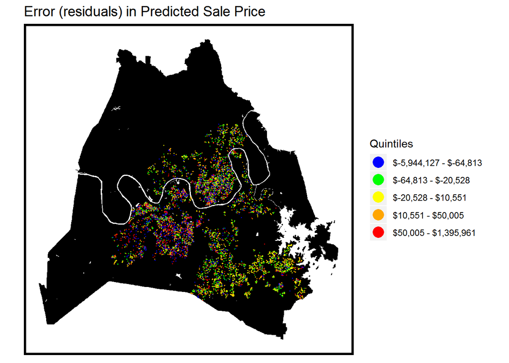

### Spatial Auto-Correlation (Moran’s I)

| Moran I statistic | 0.1432578 |
| --- | --- |
| p-value | < 2x10<sup>-16</sup> |
| Expectation | -0.0001188 |
| Variance | 0.0000502 |

Moran's I is another spatial measure that can analyze whether nearby points had similar errors. A Moran's I taking into account four neighbors gave a value of 0.14, where 1 is completely clustered, 0 is random, and -1 is completely dispersed. A slightly positive value means that there is some significant clustering (as we can see on the map above).

### Error by ZIP Code

Next, we aggregate error by ZIP code to determine if a particular ZIP code boundary has exceptional error. The plot below shows that ZIP codes with low average sale prices have a higher error, with one zip code (deep red on the map) having an average error of 80%. This means that, for an average property costing about $200,000 in this ZIP code, it's likely that our model will predict the property to cost anywhere between $40,000 or $360,000.

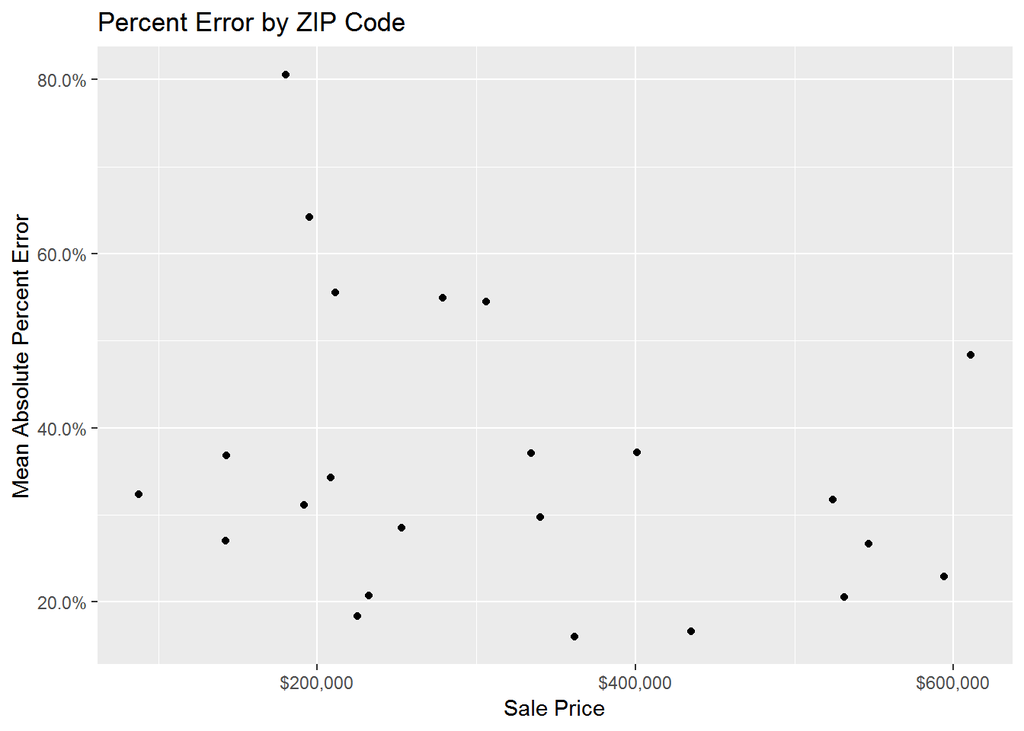

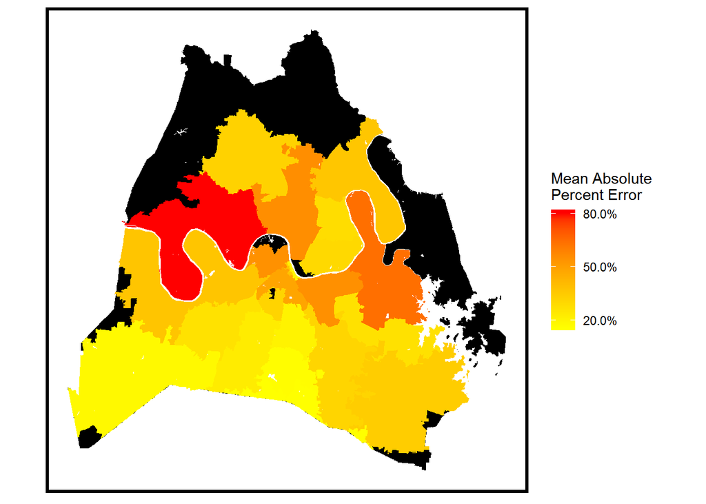

# Discussion

A few of the independent variables used in the model prove especially significant. Owner characteristics overall prove to be quite significant in predicting the sale price. Whether the owner lives in the property (OwnerOnsite) and whether the owner lives in Tennessee (OwnerInState) are especially significant, both having p-values below 2x10<sup>-16</sup>. OwnerOnsite has a coefficient of 0.18—this means that properties with owners living in them are expected to have an average increase in sale price of 100*((e^0.18)-1)%, or 19%, when compared to properties with owners living elsewhere. OwnerInState, on the other hand, interestingly has a negative relationship with sales price, with a coefficient of -0.25. This means that properties whose owners live in Tennessee have an average decrease in sale price of 100x((e<sup>-0.25</sup>)-1)%, or 22%, compared to properties whose owners live outside Tennessee. This finding suggests that more expensive properties are often owned by out of state developers or real estate holders rather than homeowners, leading to this negative correlation.

While our model has a number of spatial variables that aim to explain spatial variation in sale prices, the map of residuals reveals that there remains significant spatial variation that has gone unexplained by our model. This is supported by a Moran’s I test, which tests for spatial autocorrelation, or geographic clustering of sale values. The resulting Moran’s I statistic is 0.14, compared to an expectation of nearly 0. The expectation represents the expected statistic when there is no spatial autocorrelation. If the Moran’s I statistic is statistically significantly different from the expectation, then we can assume that there exists spatial autocorrelation in the data. With a p-value well below 0.05, this test suggests that the Moran’s I statistic and the expectation are statistically significantly different, and there remains significant spatial autocorrelation in the data that is unexplained by the model.

Looking again at the map of residuals, properties in the southwestern portion of the city in particular appear to experience a large amount of underprediction and overprediction with relation to the rest of the properties examined. Referring back to the map of sale prices, this suggests that our model is less able to accurately predict higher-value sales, and that additional variables need to be introduced to adequately explain the valuation of these sales. This may be due to the skewed nature of the sale prices, where the highest-value sales only made up a small portion of the total number of sales. More samples at higher values may help strengthen the model. Additionally, ensuring that sales from every one of a certain number of price brackets are included in every training set when developing the multiple regression cross-validation method could help to ensure that they are more accurately predicted for.

# Conclusion

If Zillow were to employ this model to predict home prices in Nashville, they would be grossly under- or over-predicting numerous properties, which would hurt both homebuyers and sellers through misinformation and would not be well received. Accordingly, we cannot recommend our model to Zillow until it has been tweaked to further diminish its error.

Particularly, as briefly explored above, spatial autocorrelation still needs to be accounted for as the model is an especially poor predictor of properties in some ZIP codes. More research into the socioeconomic structure of the city could reveal other important variables that were missed in developing the model. One simple spatial variable that could help, which may not have been captured by the census tract variable, is a neighborhood variable. If neighborhoods are more socioeconomically homogeneous than census tracts, this variable would be valuable. Additionally, the inclusion of additional sample points of more high-value properties could help the model more accurately predict these properties.